# QTL Power Calculation

2025-07-18

# QTL Power Calculation for Trait Mapping Studies

This function was developed based on method and equations described in Hu & Xu (2008) Source: https://www.nature.com/articles/hdy200825

## Assumptions

Interval mapping has been performed with a regression method either linear or logarithmic.

Calculates based on a worst-case scenario where the trait locus sits in the middle of the largest marker interval.

### Parameters

Type I error set to 0.01

#### User Input:

sampleSize: Size of the sample population used

intervalcM: Interval in centimorgans for which to calculate the power.

phenoVariance: Ratio of the phenotype that is explained by the trait locus in decimal form. Has to be a number between 0 and 1.

cross: cross type of the data set. Choose from:

- “simple” (default)
- “BC” (Back cross)
- “DH” (Double Haploid)
- “RIL” (Recombinant Inbred Line)

```r
QTL_Power_calc <- function(sampleSize,
                           intervalcM,
                           phenoVariance,
                           cross = "simple")
{

  ## 1 # find recombination rate
  recomb = 0.5*(1-exp(-(intervalcM/sampleSize)))

  ## 2 # Calculate the Qx2
  # based on mating strategy:
  ## if cross = "simple"
  if(cross == "simple") {
    Qx2 = ((1-2*recomb)^2)/(2-4*recomb*(1-recomb))
  }

  # if cross = backcross ("BC")
  if(cross == "BC") {
    Qx2 = ((1-2*recomb)^2)/(4-8*(1-recomb)*recomb)
  }

  # if cross is double haploid (DH)
  if(cross == "DH") {
    Qx2 = 2-(1/(1-2*(1-recomb))*recomb)
  }

  # if cross us recombinant inbred line ("RIL")
  if(cross == "RIL") {
    Qx2 = 1 - ((2*recomb)/(1+4*recomb^2))
  }

  ## 3 # Calculate the squared QTL effect a^2
  # phenoVariance = 0.1
  effect <- (phenoVariance/(0.5*(1 - phenoVariance)))

  ## 4 # Calculate the non-centrality parameters
  nonCent <- sampleSize * Qx2 * (effect/(1 + effect * (0.5 - Qx2)))

  ## 5 # Calculate type 1 error (=0.01):
  type_1 <- qf(0.99, 1, sampleSize)

  ## 6 # Calculate the Type 2 error, F distribution
  type_2 <- pf(type_1, 1, sampleSize, nonCent)

  # 7 # Calculate statistical power to detect QTL
  power_r <- 1-type_2
  print(power_r)
}
```

## Example 1:

- 100 samples
- 5 cM interval
- Explaining 10% of the phenotypic variance
- Cross type: “simple”

```r
QTL_Power_calc(sampleSize = 100,
               intervalcM = 5,
               phenoVariance = 0.1,
               cros = "simple")
```

```
## [1] 0.7291779
```

This would only have a 72.9% chance of accurately locating the causative loci.

## Example 2:

- 200 samples
- 10 cM interval
- Explaining 75% of the phenotypic variance
- Cross type: Back cross

```r
QTL_Power_calc(200, 10, 0.75, "BC")
```

```
## [1] 1
```

There would be enough power to detect trait loci.

## The function can also be used on a vector of data points to plot power curves

### Example 3: For a series of cM intervals:

```r
intervals <- seq(0, 50, by=1) # in cM
power_vals <- sapply(intervals, function(i) {
  QTL_Power_calc(sampleSize = 50,
                 intervalcM = i,
                 phenoVariance = 0.5)
})
```

```
## [1] 0.9999894
## [1] 0.9999808
## [1] 0.9999663
## [1] 0.9999423
## [1] 0.9999037
## [1] 0.9998432
## [1] 0.9997508
## [1] 0.999613
## [1] 0.9994118
## [1] 0.9991244
## [1] 0.9987222
## [1] 0.9981703
## [1] 0.9974269
## [1] 0.9964433
## [1] 0.9951641
```

[output cut: 36 more lines]

This information can then be plotted as a power curve with a line at 95%:

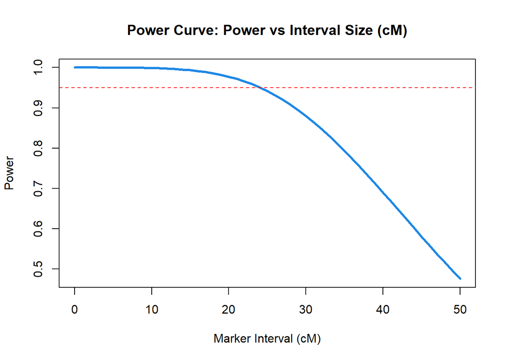

```r
plot(intervals, power_vals, type = "l", lwd = 3,
     col = "#1E88E5",
     xlab = "Marker Interval (cM)",
     ylab = "Power",
     main = "Power Curve: Power vs Interval Size (cM)")
abline(h = 0.95, col = "red", lty = 2)
```

### Example 4: For a series sample sizes:

```r
samples <- seq(1, 50, by=1) # sample size
power_sample <- sapply(samples, function(i) {
  QTL_Power_calc(sampleSize = i,
                 intervalcM = 3,
                 phenoVariance = 0.5)
})
```

```
## [1] 0.01001239
## [1] 0.01098037
## [1] 0.01582096
## [1] 0.02678362
## [1] 0.04545295
## [1] 0.0730441
## [1] 0.1101199
## [1] 0.156389
## [1] 0.2107341
## [1] 0.2714057
## [1] 0.3362892
## [1] 0.4031704
## [1] 0.4699567
## [1] 0.5348315
## [1] 0.5963419
```

[output cut: 35 more lines]

The power curve can then be plotted like this:

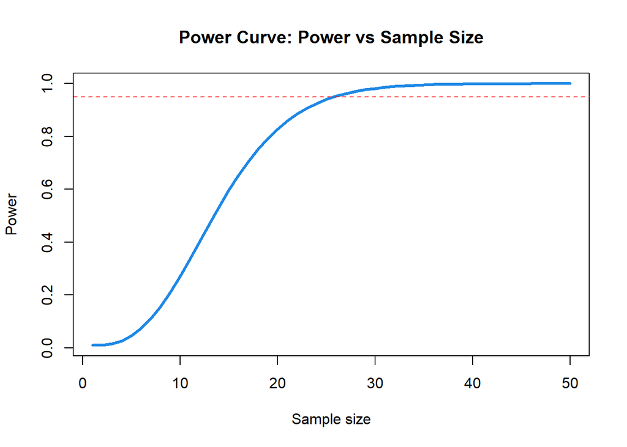

```r
plot(samples, power_sample, type = "l", lwd = 3,
     col = "#1E88E5",
     xlab = "Sample size",
     ylab = "Power",
     main = "Power Curve: Power vs Sample Size")
abline(h = 0.95, col = "red", lty = 2)
```

### Example 5: For a series of phenotypic variance estimates:

```r
pheno <- seq(0, 1, by=0.02) # sample size
power_pheno <- sapply(pheno, function(i) {
  QTL_Power_calc(sampleSize = 50,
                 intervalcM = 3,
                 phenoVariance = i)
})
```

```
## [1] 0.01
## [1] 0.05186885
## [1] 0.1105254
## [1] 0.1830397
## [1] 0.2657056
## [1] 0.3544425
## [1] 0.4451691
## [1] 0.5341243
## [1] 0.6181148
## [1] 0.6946783
## [1] 0.76216
## [1] 0.8197063
## [1] 0.8671908
## [1] 0.905088
## [1] 0.9343168
```

[output cut: 36 more lines]

The power curve can then be plotted like this:

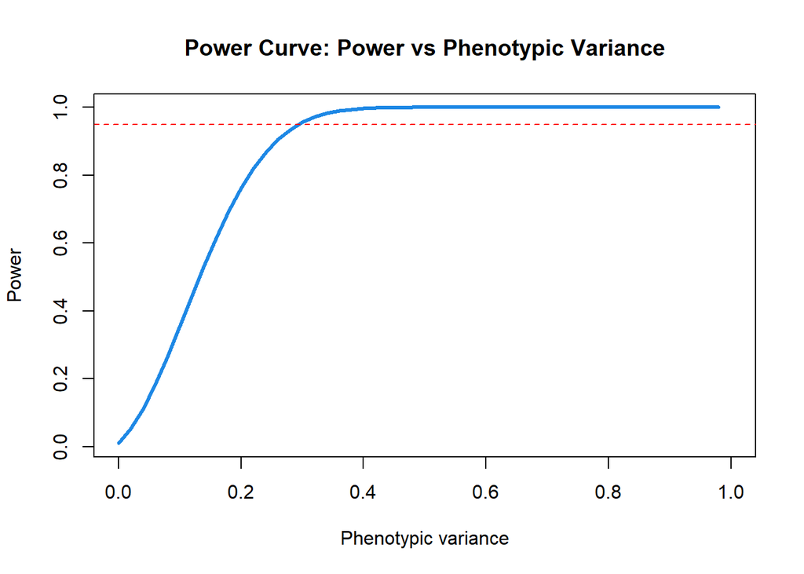

```r
plot(pheno, power_pheno, type = "l", lwd = 3,
     col = "#1E88E5",
     xlab = "Phenotypic variance",
     ylab = "Power",
     main = "Power Curve: Power vs Phenotypic Variance")
abline(h = 0.95, col = "red", lty = 2)
```